# STOR 455 Content: Data Analysis

This course from the *UNC Department of Statistics and Operations Research* focuses on the primary techniques of regression analysis. The topics include simple to multiple linear and logistic regression, matrix representation of the regression model, statistical inferences for regression model, diagnostics and remedies for multicollinearity, outlier and influential cases, polynomial regression and interaction regression models, model selection, weighted least square procedure for unequal error variances, and ANOVA model and test.

# Simple Linear Regression

```r
library(Stat2Data) #lots of datasets
library(tidyverse) #ggplot, readr, tidyr, etc
UsedCarLot <- read_csv("/Users/abwilli/Downloads/UsedCarLot.csv")
#car dataset
head(UsedCarLot)
```

| year | price | mileage | make | model |
| --- | --- | --- | --- | --- |
| 2014 | 33.888 | 17.714 | Chevrolet\xa0 | Silverado |
| 2014 | 13.995 | 35.535 | VW | Jetta |
| 2013 | 9.995 | 55.800 | VW | Jetta |
| 2004 | 6.666 | 135.900 | Nissan | Altima |
| 2016 | 12.950 | 35.517 | Kia | Soul |
| 2016 | 29.877 | 15.253 | NIssan | Frontier |

```r
#filter set
Honda <- filter(UsedCarLot, UsedCarLot$make == "Honda")
#create variable
Honda <- mutate(Honda, age = 2018 - year)

#build linear model (lm) - comparing price and age
mod1 <- lm(price~age, data = Honda)
summary(mod1)
```

```
##
## Call:
## lm(formula = price ~ age, data = Honda)
##
## Residuals:
##    Min     1Q Median     3Q    Max
## -7.339 -3.865 -1.368  2.223 15.481
##
## Coefficients:
##             Estimate Std. Error t value Pr(>|t|)
## (Intercept)  40.1322     1.1396   35.22   <2e-16 ***
## age          -2.2085     0.1473  -14.99   <2e-16 ***
## ---
## Signif. codes:  0 '***' 0.001 '**' 0.01 '*' 0.05 '.' 0.1 ' ' 1
##
## Residual standard error: 5.161 on 48 degrees of freedom
## Multiple R-squared:  0.824,  Adjusted R-squared:  0.8203
## F-statistic: 224.7 on 1 and 48 DF,  p-value: < 2.2e-16
```

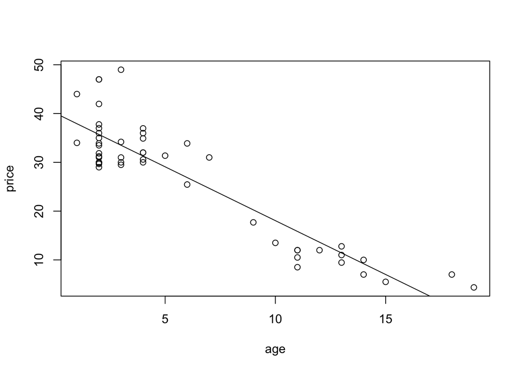

```r
plot(price~age, data = Honda)
abline(mod1)
```

## Residual Analysis

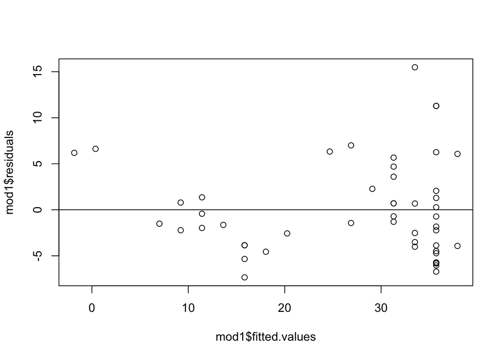

```r
#Zero Mean Condition
plot(mod1$residuals ~ mod1$fitted.values)
abline(0,0)
```

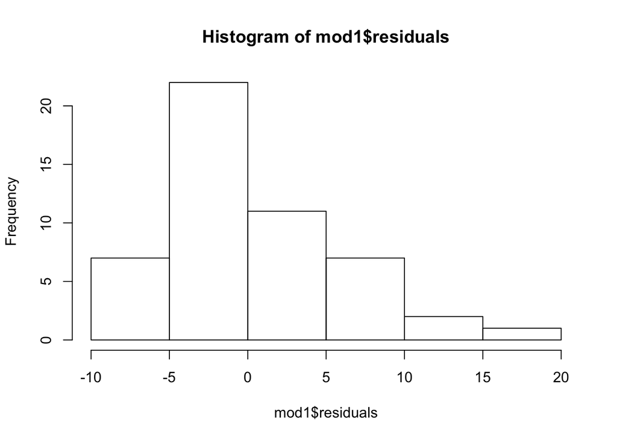

```r
#Independence Condition
hist(mod1$residuals)
```

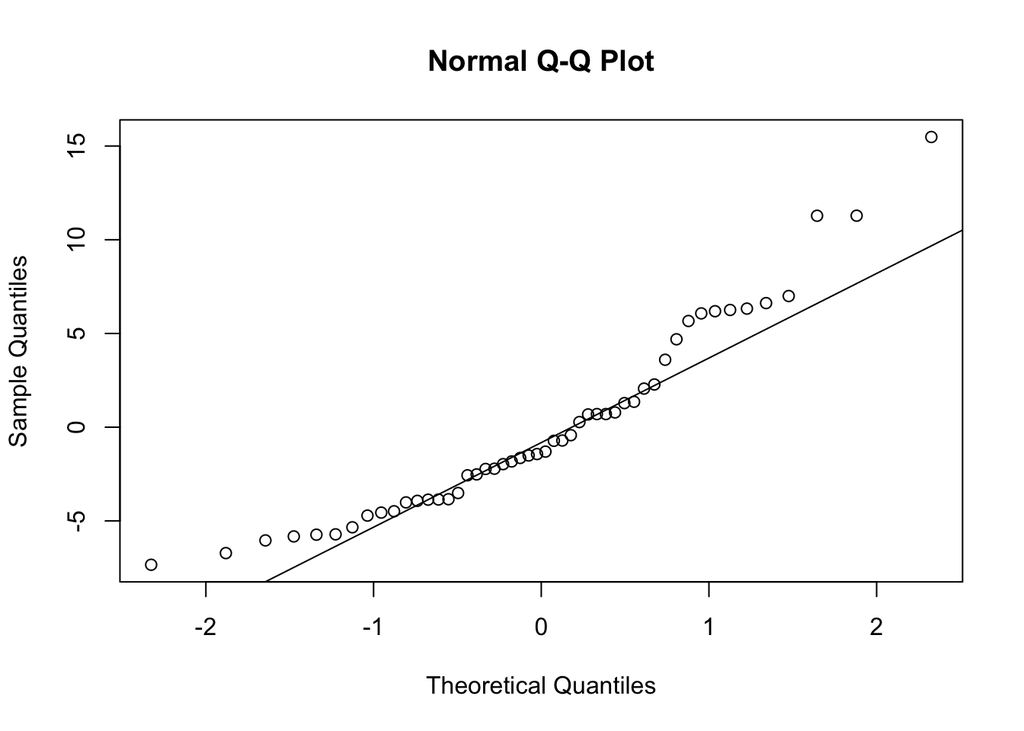

```r
#Normality Condition
qqnorm(mod1$residuals)
qqline(mod1$residuals)
```

```r
#biggest residual
i = which.max(mod1$residuals)
Honda[i, 1:4 ]
```

| year | price | mileage | make |
| --- | --- | --- | --- |
| 2015 | 48.988 | 38.002 | Honda |

```r
rstandard(mod1)[i]
```

```
##       37
## 3.041209
```

```r
rstudent(mod1)[i]
```

```
##       37
## 3.349296
```

Standardized/Studentized residual values that are greater than 2 or 3 are cause for concern and may be an outlier.

## Prediction, Confidence Interval & Model Effectiveness

```r
anova(mod1)
```

|  | Df | Sum Sq | Mean Sq | F value | Pr(>F) |
| --- | --- | --- | --- | --- | --- |
| age | 1 | 5983.960 | 5983.95979 | 224.6733 | 9.854431e-20 |
| Residuals | 48 | 1278.434 | 26.63404 | NA | NA |

```r
summary(mod1)
```

```
##
## Call:
## lm(formula = price ~ age, data = Honda)
##
## Residuals:
##    Min     1Q Median     3Q    Max
## -7.339 -3.865 -1.368  2.223 15.481
##
## Coefficients:
##             Estimate Std. Error t value Pr(>|t|)
## (Intercept)  40.1322     1.1396   35.22   <2e-16 ***
## age          -2.2085     0.1473  -14.99   <2e-16 ***
## ---
## Signif. codes:  0 '***' 0.001 '**' 0.01 '*' 0.05 '.' 0.1 ' ' 1
##
## Residual standard error: 5.161 on 48 degrees of freedom
## Multiple R-squared:  0.824,  Adjusted R-squared:  0.8203
## F-statistic: 224.7 on 1 and 48 DF,  p-value: < 2.2e-16
```

```r
newx=data.frame(age=5)
predict.lm(mod1, newx, interval="confidence", level = .90)
```

```
##       fit      lwr      upr
## 1 29.0895 27.84353 30.33547
```

```r
predict.lm(mod1, newx, interval="prediction", level = .90)
```

```
##       fit      lwr      upr
## 1 29.0895 20.34444 37.83457
```

## Transformations

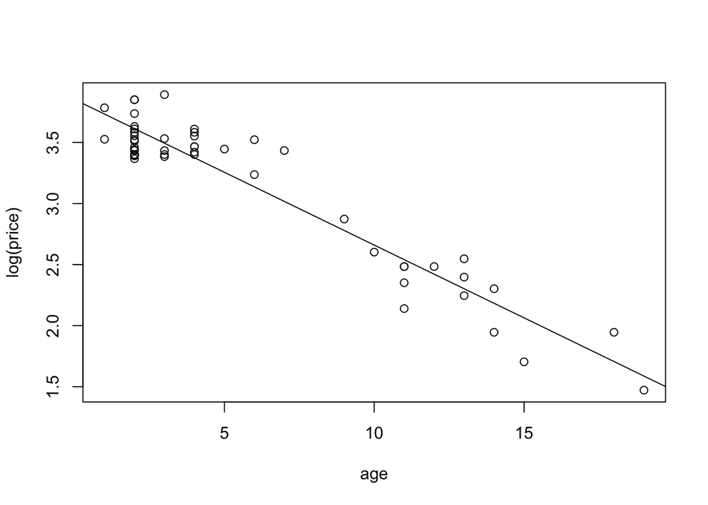

```r
#log transformation
plot(log(price) ~ age, data = Honda)
mod_trans = lm(log(price)~age, data = Honda)
abline(mod_trans)
```

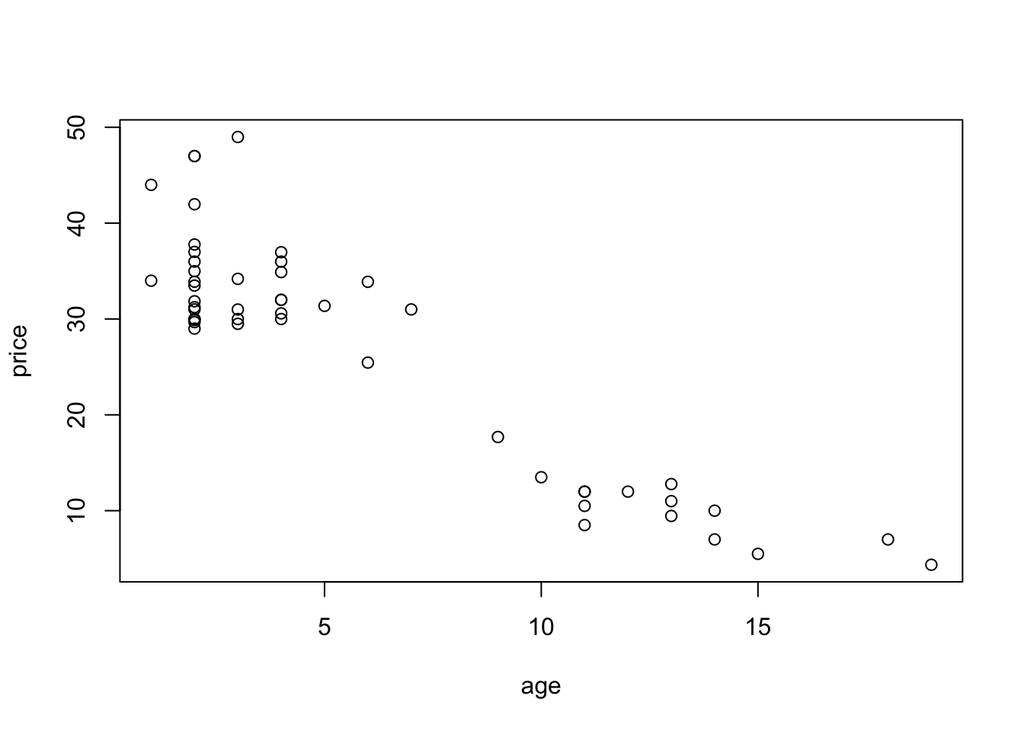

```r
plot(price ~ age^2, data = Honda)
```

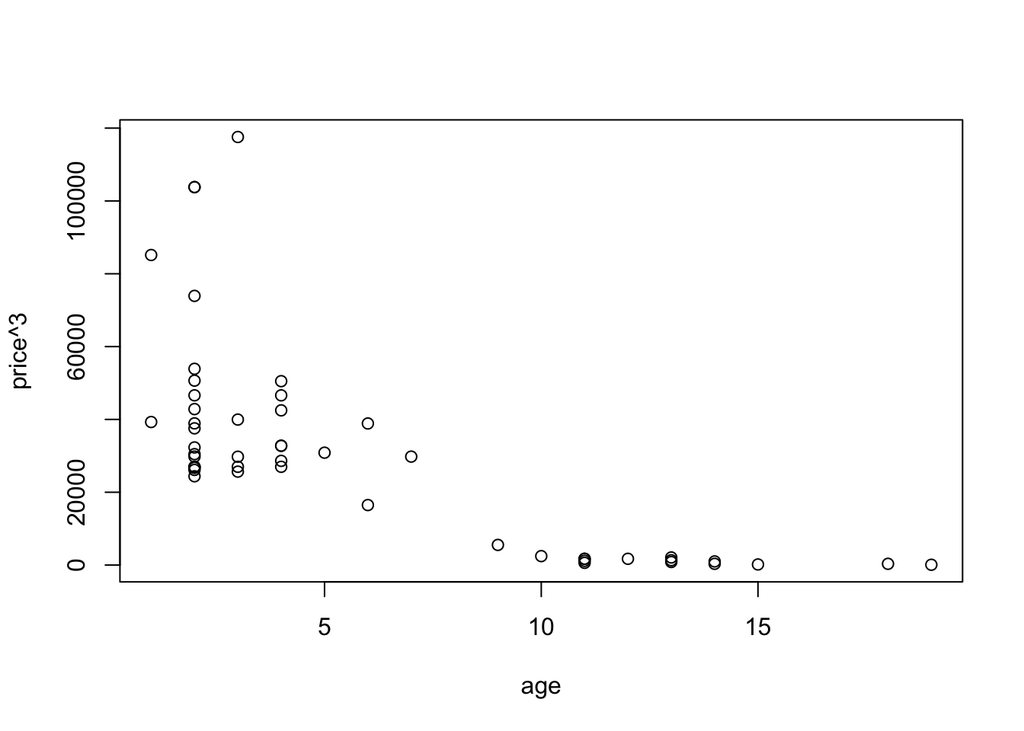

```r
plot(price^3 ~ age, data = Honda)
```

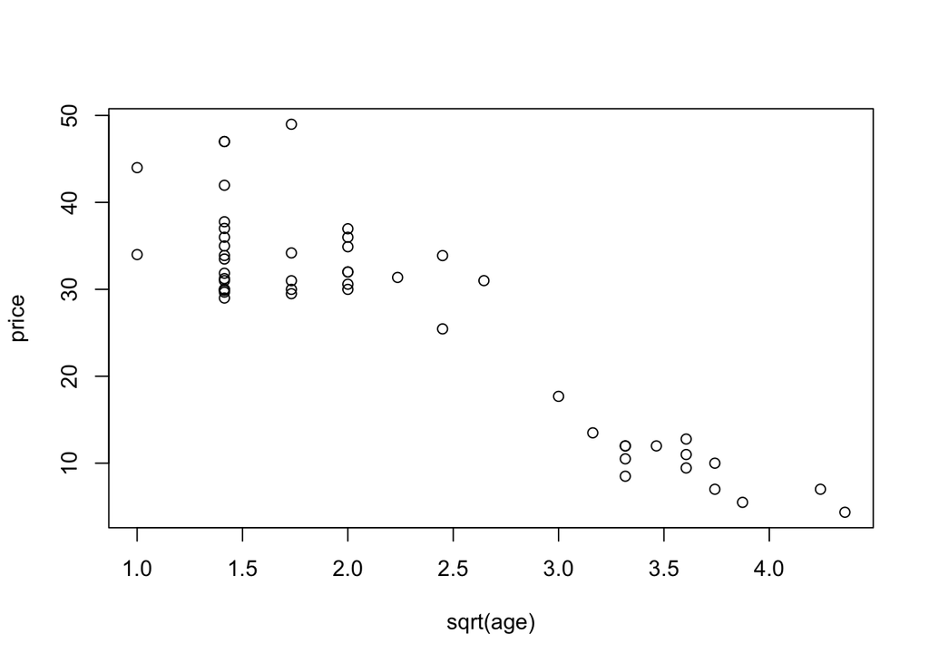

```r
plot(price~ sqrt(age), data = Honda)
```

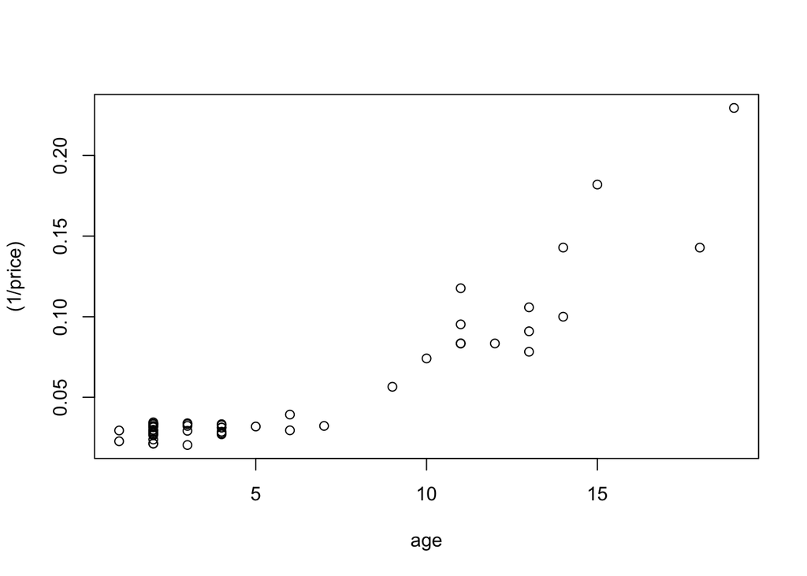

```r
plot((1/price) ~ age, data = Honda)
```

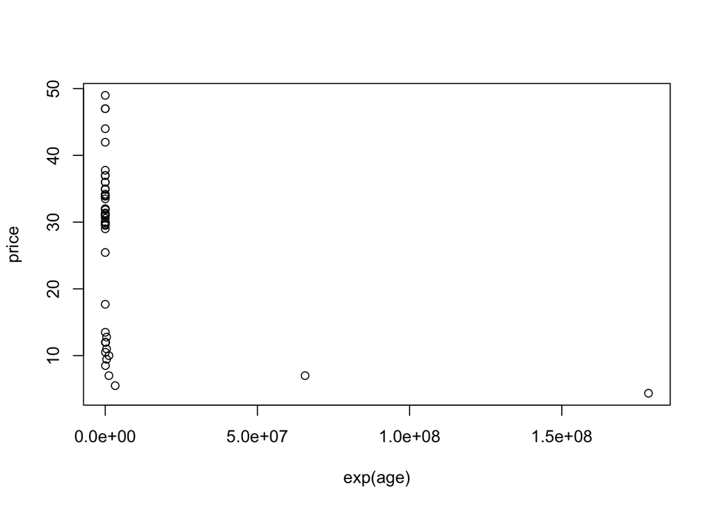

```r
plot(price~ exp(age), data = Honda)
```

## Anova: Does the model explain a significant amount of the total variability?

```r
anova(mod1)
```

|  | Df | Sum Sq | Mean Sq | F value | Pr(>F) |
| --- | --- | --- | --- | --- | --- |
| age | 1 | 5983.960 | 5983.95979 | 224.6733 | 9.854431e-20 |
| Residuals | 48 | 1278.434 | 26.63404 | NA | NA |

```r
anova(mod_trans)
```

|  | Df | Sum Sq | Mean Sq | F value | Pr(>F) |
| --- | --- | --- | --- | --- | --- |
| age | 1 | 17.439364 | 17.43936450 | 467.0928 | 2.207742e-26 |
| Residuals | 48 | 1.792127 | 0.03733597 | NA | NA |

Null hypothesis: The mdoel does not explain the variablity in the data Alternate hypothesis: The model accounts for variablity, and is strong

The **Sum Square/Mean Square of the residuals** should be low, the F-value should be high, the P-value should be lower than 0.5 (reject the null and show the model is effective)

The **F-statistic**: indicates whether the linear regression model provides a better fit to the data than a model that contains no independent variables.

**R-squared**: proportion of total variablity that is explained by the model, shows how much more accurate the least squares line is than a model based on the mean of data.

# Multiple Linear Regression Model

## 1) t-test for correlation between variables

```r
data(Houses)
cor.test(Houses$Price, Houses$Size)
```

```
##
##  Pearson's product-moment correlation
##
## data:  Houses$Price and Houses$Size
## t = 3.9871, df = 18, p-value = 0.0008643
## alternative hypothesis: true correlation is not equal to 0
## 95 percent confidence interval:
##  0.3476582 0.8651583
## sample estimates:
##       cor
## 0.6848219
```

## 2) Individual t-tests

```r
mod1 = lm(Price~Size+Lot, data = Houses)
summary(mod1)
```

```
##
## Call:
## lm(formula = Price ~ Size + Lot, data = Houses)
##
## Residuals:
##    Min     1Q Median     3Q    Max
## -79532 -28464   3713  21450  73507
##
## Coefficients:
##              Estimate Std. Error t value Pr(>|t|)
## (Intercept) 34121.649  29716.458   1.148   0.2668
## Size           23.232     17.700   1.313   0.2068
## Lot             5.657      3.075   1.839   0.0834 .
## ---
## Signif. codes:  0 '***' 0.001 '**' 0.01 '*' 0.05 '.' 0.1 ' ' 1
##
## Residual standard error: 47400 on 17 degrees of freedom
## Multiple R-squared:  0.5571, Adjusted R-squared:  0.505
## F-statistic: 10.69 on 2 and 17 DF,  p-value: 0.000985
```

## 3) R squared value

## percent of the variablity explained by a linear combination of these predictors

## 4) Anova that is not split sequentially for each predictor

```r
# ANOVA for Regression - formatted for whole model
# Argument: model - an lm model

anova455=function(model){
  numpred=model$rank-1
  dferror=df.residual(model)
  dfmodel=numpred
  dftotal=dfmodel+dferror
  sse=sum(model$residual^2)
  ssmodel=sum(model$effects[2:(numpred+1)]^2)
  sstotal=ssmodel+sse
  msmodel=ssmodel/dfmodel
  mse=sse/dferror
  fstat=msmodel/mse
  pvalue=1-pf(fstat,dfmodel,dferror)
  df=c(dfmodel,dferror,dftotal)
  ss=c(ssmodel,sse,sstotal)
  ms=c(msmodel,mse,0)
  f=c(fstat,0,0)
  p=c(pvalue,0,0)
  table=data.frame(df,ss,ms,f,p)
  table[2,4:5]=NA
  table[3,3:5]=NA

  colnames(table)=c("Df","Sum Sq","Mean Sq","F value","P(>F)")
  row.names(table)=c("Model","Error","Total")
  class(table)=c("anova","data.frame")
  structure(table,
            heading=c("ANOVA Table",
                      paste("Model:",
                            formula(model)[2],
                            formula(model)[1],
                            formula(model)[3],"\n")
            )
  )
}


anova455(mod1)
```

|  | Df | Sum Sq | Mean Sq | F value | P(>F) |
| --- | --- | --- | --- | --- | --- |
| Model | 2 | 48048189470 | 24024094735 | 10.69245 | 0.0009850346 |
| Error | 17 | 38196058530 | 2246826972 | NA | NA |
| Total | 19 | 86244248000 | NA | NA | NA |

## look at p-value and f-statistic for the overall effectiveness of the model

- **F-statistic** shows if there is multicolinearity in the model
- Adding additional predictors increases SSModel, Decreases SSE, and increases Rsquared

## 5) **VIF** - Variable Inflation Factor

- If vif is greater than 10, then there must be some kind of colinearlity

```r
#run the code below to acivate a VIF function
# for multiple regression models

vif<- function(model, ...) {
  V <- summary(model)$cov.unscaled
  Vi <- crossprod(model.matrix(model))
  nam <- names(coef(model))
  if(k <- match("(Intercept)", nam, nomatch = F)) {
    v1 <- diag(V)[-k]
    v2 <- (diag(Vi)[-k] - Vi[k, -k]^2/Vi[k,k])
    nam <- nam[-k]
  } else {
    v1 <- diag(V)
    v2 <- diag(Vi)
    warning("No intercept term detected.  Results may
surprise.")
  }
  structure(v1*v2, names = nam)
}

vif(mod1)
```

```
##     Size      Lot
## 2.427732 2.427732
```

## 6)Transform Variables and analyze again

## Comparing Models:

- Look for large R squared
- Look for adjusted R squared
- Look at individual t-tests
- All Regular Subsets

```r
#requires leaps package
library(leaps)

StateSAT <- read.csv("/Users/abwilli/Downloads/StateSAT.csv")

all=regsubsets(SAT~Takers+Income+Years+Public+Expend+Rank,
        data=StateSAT,nbest=2)

#Function to show results for regsubsets
# input should be the result from regsubsets

ShowSubsets=function(regout){
  z=summary(regout)
  q=as.data.frame(z$outmat)
  q$Rsq=round(z$rsq*100,2)
  q$adjRsq=round(z$adjr2*100,2)
  q$Cp=round(z$cp,2)
  return(q)
}


ShowSubsets(all)
```

|  | Takers | Income | Years | Public | Expend | Rank | Rsq | adjRsq | Cp |
| --- | --- | --- | --- | --- | --- | --- | --- | --- | --- |
| 1 ( 1 ) |  |  |  |  |  | * | 77.42 | 76.95 | 34.03 |
| 1 ( 2 ) | * |  |  |  |  |  | 73.58 | 73.03 | 47.64 |
| 2 ( 1 ) |  |  | * |  |  | * | 84.71 | 84.05 | 10.22 |
| 2 ( 2 ) |  |  |  |  | * | * | 80.54 | 79.71 | 24.97 |
| 3 ( 1 ) |  |  | * |  | * | * | 87.11 | 86.27 | 3.69 |
| 3 ( 2 ) |  | * | * |  |  | * | 85.84 | 84.91 | 8.21 |
| 4 ( 1 ) |  |  | * | * | * | * | 87.71 | 86.61 | 3.58 |
| 4 ( 2 ) | * |  | * |  | * | * | 87.67 | 86.57 | 3.72 |
| 5 ( 1 ) | * |  | * | * | * | * | 87.87 | 86.49 | 5.00 |
| 5 ( 2 ) |  | * | * | * | * | * | 87.73 | 86.34 | 5.48 |

[output cut: 1 more lines]

## Mallow’s Cp

- R2, Adjusted R2, SSE, all depend only on the predictors in the model being evaluated – NOT the other potential predictors in the pool.
- Cp must be **small** for a good set of predictors

## Prediction Selection Methods

- All Subsets
- Backward Elimination
- Forward Selection
- Stepwise Regression

## Backwards Elimination

```r
# Fit the full model
Full=lm(SAT~Takers+Income+Years+Public+Expend+Rank,
          data=StateSAT)
  # Find the MSE for the full model
MSE=(summary(Full)$sigma)^2

# Backward: use the step( ) command starting with the full model

step(Full,scale=MSE)
```

```
## Start:  AIC=7
## SAT ~ Takers + Income + Years + Public + Expend + Rank
##
##          Df Sum of Sq   RSS      Cp
## - Income  1       2.0 29844  5.0029
## - Takers  1     332.4 30175  5.4789
## - Public  1     445.8 30288  5.6424
## <none>                29842  7.0000
## - Expend  1    4744.9 34587 11.8369
## - Years   1    8897.8 38740 17.8208
## - Rank    1   11223.0 41065 21.1712
##
## Step:  AIC=5
## SAT ~ Takers + Years + Public + Expend + Rank
##
##          Df Sum of Sq   RSS      Cp
## - Takers  1     401.3 30246  3.5812
## - Public  1     495.5 30340  3.7169
## <none>                29844  5.0029
## - Expend  1    6904.4 36749 12.9515
## - Years   1    9219.7 39064 16.2876
## - Rank    1   11645.9 41490 19.7836
##
## Step:  AIC=3.58
## SAT ~ Years + Public + Expend + Rank
##
##          Df Sum of Sq    RSS       Cp
## <none>                 30246   3.5812
## - Public  1      1462  31708   3.6884
## - Expend  1      7343  37589  12.1618
## - Years   1      8837  39083  14.3141
## - Rank    1    184786 215032 267.8394
```

```
##
## Call:
## lm(formula = SAT ~ Years + Public + Expend + Rank, data = StateSAT)
##
## Coefficients:
## (Intercept)        Years       Public       Expend         Rank
##   -204.5982      21.8905      -0.6638       2.2416      10.0032
```

```r
#R uses Cp (AIC) to pick next model
```

## Forward Selection

```r
# Fit the full model
Full=lm(SAT~Takers+Income+Years+Public+Expend+Rank,
          data=StateSAT)
# Find the MSE for the full model
MSE=(summary(Full)$sigma)^2

# Start with a model with NO predictors
none=lm(SAT~1,data=StateSAT)

#Specify the direction
step(none,scope=list(upper=Full),scale=MSE,direction="forward")
```

```
## Start:  AIC=306.48
## SAT ~ 1
##
##          Df Sum of Sq    RSS      Cp
## + Rank    1    190471  55539  34.027
## + Takers  1    181024  64987  47.639
## + Income  1     84038 161973 187.388
## + Years   1     26948 219063 269.648
## + Public  1      1589 244422 306.189
## <none>                246011 306.478
## + Expend  1       973 245038 307.076
##
## Step:  AIC=34.03
## SAT ~ Rank
##
##          Df Sum of Sq   RSS     Cp
## + Years   1   17913.6 37626 10.215
## + Expend  1    7671.0 47868 24.974
## + Income  1    4601.1 50938 29.397
## + Public  1    3847.7 51692 30.483
## + Takers  1    1761.8 53778 33.488
## <none>                55539 34.027
##
## Step:  AIC=10.22
## SAT ~ Rank + Years
##
##          Df Sum of Sq   RSS      Cp
## + Expend  1    5917.6 31708  3.6884
## + Income  1    2782.4 34843  8.2059
## <none>                37626 10.2152
## + Takers  1     778.7 36847 11.0931
## + Public  1      37.0 37589 12.1618
##
## Step:  AIC=3.69
## SAT ~ Rank + Years + Expend
##
##          Df Sum of Sq   RSS     Cp
## + Public  1   1462.46 30246 3.5812
## <none>                31708 3.6884
## + Takers  1   1368.28 30340 3.7169
## + Income  1    848.47 30860 4.4659
##
## Step:  AIC=3.58
## SAT ~ Rank + Years + Expend + Public
##
##          Df Sum of Sq   RSS     Cp
## <none>                30246 3.5812
## + Takers  1    401.32 29844 5.0029
## + Income  1     70.95 30175 5.4789
```

```
##
## Call:
## lm(formula = SAT ~ Rank + Years + Expend + Public, data = StateSAT)
##
## Coefficients:
## (Intercept)         Rank        Years       Expend       Public
##   -204.5982      10.0032      21.8905       2.2416      -0.6638
```

## Stepwise Regression

```r
# Fit the full model
Full=lm(SAT~Takers+Income+Years+Public+Expend+Rank,
          data=StateSAT)
# Find the MSE for the full model
MSE=(summary(Full)$sigma)^2

# Start with a model with NO predictors
none=lm(SAT~1,data=StateSAT)

# Don’t specify a direction
step(none,scope=list(upper=Full),scale=MSE)
```

```
## Start:  AIC=306.48
## SAT ~ 1
##
##          Df Sum of Sq    RSS      Cp
## + Rank    1    190471  55539  34.027
## + Takers  1    181024  64987  47.639
## + Income  1     84038 161973 187.388
## + Years   1     26948 219063 269.648
## + Public  1      1589 244422 306.189
## <none>                246011 306.478
## + Expend  1       973 245038 307.076
##
## Step:  AIC=34.03
## SAT ~ Rank
##
##          Df Sum of Sq    RSS      Cp
## + Years   1     17914  37626  10.215
## + Expend  1      7671  47868  24.974
## + Income  1      4601  50938  29.397
## + Public  1      3848  51692  30.483
## + Takers  1      1762  53778  33.488
## <none>                 55539  34.027
## - Rank    1    190471 246011 306.478
##
## Step:  AIC=10.22
## SAT ~ Rank + Years
##
##          Df Sum of Sq    RSS       Cp
## + Expend  1      5918  31708   3.6884
## + Income  1      2782  34843   8.2059
## <none>                 37626  10.2152
## + Takers  1       779  36847  11.0931
## + Public  1        37  37589  12.1618
## - Years   1     17914  55539  34.0268
## - Rank    1    181437 219063 269.6479
##
## Step:  AIC=3.69
## SAT ~ Rank + Years + Expend
##
##          Df Sum of Sq    RSS       Cp
## + Public  1      1462  30246   3.5812
## <none>                 31708   3.6884
## + Takers  1      1368  30340   3.7169
## + Income  1       848  30860   4.4659
## - Expend  1      5918  37626  10.2152
## - Years   1     16160  47868  24.9737
## - Rank    1    185667 217375 269.2161
##
## Step:  AIC=3.58
## SAT ~ Rank + Years + Expend + Public
##
##          Df Sum of Sq    RSS       Cp
## <none>                 30246   3.5812
## - Public  1      1462  31708   3.6884
## + Takers  1       401  29844   5.0029
## + Income  1        71  30175   5.4789
## - Expend  1      7343  37589  12.1618
## - Years   1      8837  39083  14.3141
## - Rank    1    184786 215032 267.8394
```

```
##
## Call:
## lm(formula = SAT ~ Rank + Years + Expend + Public, data = StateSAT)
##
## Coefficients:
## (Intercept)         Rank        Years       Expend       Public
##   -204.5982      10.0032      21.8905       2.2416      -0.6638
```

- pick the one with the lowest AIC and highest p-value significance

## Polynomial Regression

## Test to Compare Two Regression Lines

```r
Pulsef17 <- read.csv("/Users/abwilli/Downloads/PulseF17.csv")

#y ~ Quantitative + Indicator(Dummy) + Interaction
modelPint=lm(Active~Rest+Gender+Rest*Gender,data=Pulsef17)

#Create new variables with I()
modSAT2I = lm(SAT~Takers + I(Takers^2), data =StateSAT)
```

## Quadratic Model

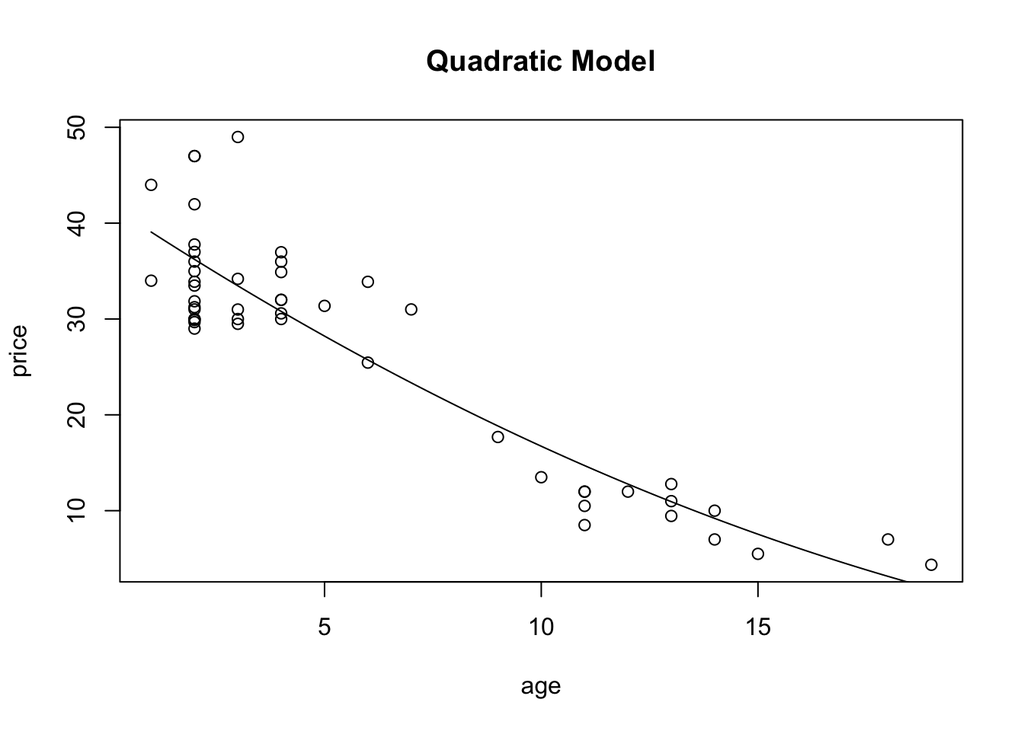

```r
quadmodH <- lm(price~age + I(age^2), data = Honda)
plot(price~age, main = "Quadratic Model", data = Honda)
curve(summary(quadmodH)$coefficients[1]+summary(quadmodH)$coefficients[2]*x+summary(quadmodH)$coefficients[3]*x^2, add=TRUE)
```

## Cubic Model

```r
cubemodH = lm(price~age+I(age^2)+ I(age^3), data = Honda)
summary(cubemodH)
```

```
##
## Call:
## lm(formula = price ~ age + I(age^2) + I(age^3), data = Honda)
##
## Residuals:
##     Min      1Q  Median      3Q     Max
## -6.5489 -3.2592 -0.7405  2.1446 14.5752
##
## Coefficients:
##              Estimate Std. Error t value Pr(>|t|)
## (Intercept) 35.820321   3.088378  11.598 2.97e-15 ***
## age          0.622092   1.599862   0.389   0.6992
## I(age^2)    -0.410710   0.191429  -2.146   0.0372 *
## I(age^3)     0.015652   0.006457   2.424   0.0193 *
## ---
## Signif. codes:  0 '***' 0.001 '**' 0.01 '*' 0.05 '.' 0.1 ' ' 1
##
## Residual standard error: 4.874 on 46 degrees of freedom
## Multiple R-squared:  0.8495, Adjusted R-squared:  0.8397
## F-statistic: 86.55 on 3 and 46 DF,  p-value: < 2.2e-16
```

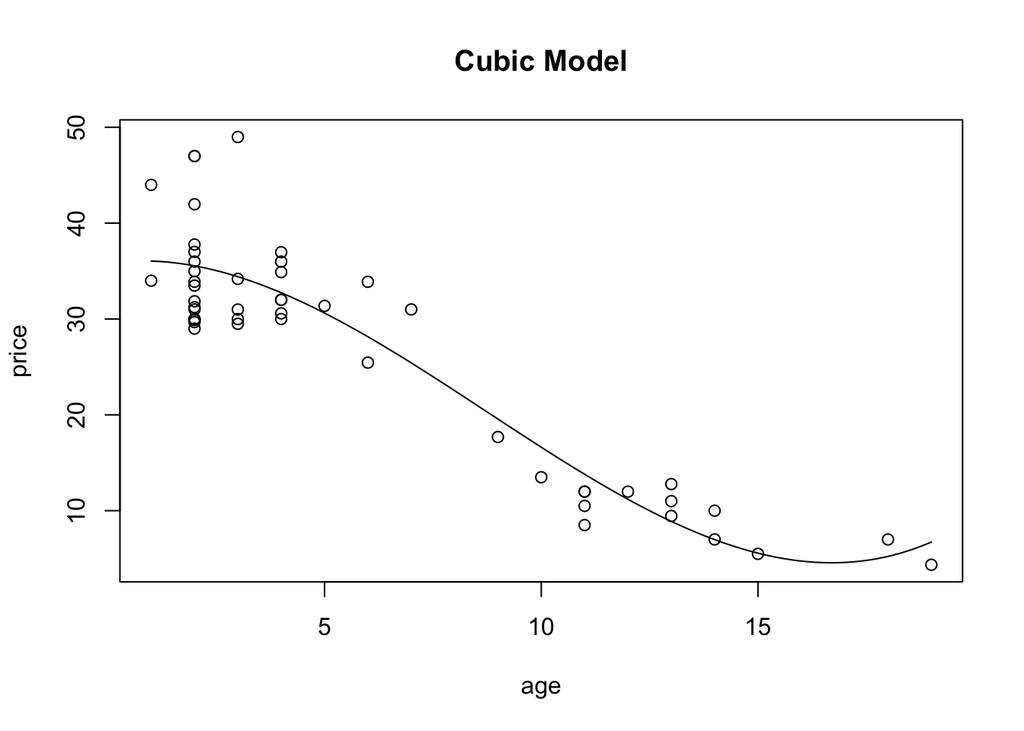

```r
plot(price~age, main = "Cubic Model", data = Honda)
curve(summary(cubemodH)$coefficients[1]+summary(cubemodH)$coefficients[2]*x+summary(cubemodH)$coefficients[3]*x^2 + summary(cubemodH)$coefficients[4]*x^3, add=TRUE)
```

## Second Order Model

# Residual Analysis

```r
secondOrdMod = lm(price~age+mileage+I(age^2) +I(mileage^2) + I(age*mileage), data = Honda)
summary(secondOrdMod)
```

```
##
## Call:
## lm(formula = price ~ age + mileage + I(age^2) + I(mileage^2) +
##     I(age * mileage), data = Honda)
##
## Residuals:
##     Min      1Q  Median      3Q     Max
## -5.5573 -3.0531 -0.8175  2.0774 16.3496
##
## Coefficients:
##                    Estimate Std. Error t value Pr(>|t|)
## (Intercept)      43.4723800  1.7288502  25.145  < 2e-16 ***
## age              -1.0006058  0.6910388  -1.448 0.154713
## mileage          -0.2300254  0.0619104  -3.715 0.000569 ***
## I(age^2)         -0.0423076  0.1324952  -0.319 0.751000
## I(mileage^2)      0.0002007  0.0008043   0.250 0.804115
## I(age * mileage)  0.0087736  0.0206438   0.425 0.672910
## ---
## Signif. codes:  0 '***' 0.001 '**' 0.01 '*' 0.05 '.' 0.1 ' ' 1
##
## Residual standard error: 4.361 on 44 degrees of freedom
## Multiple R-squared:  0.8848, Adjusted R-squared:  0.8717
## F-statistic: 67.57 on 5 and 44 DF,  p-value: < 2.2e-16
```

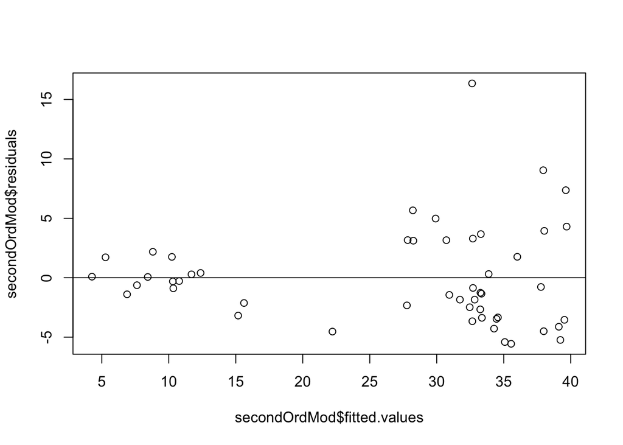

```r
plot(secondOrdMod$residuals~secondOrdMod$fitted.values)
abline(0,0)
```

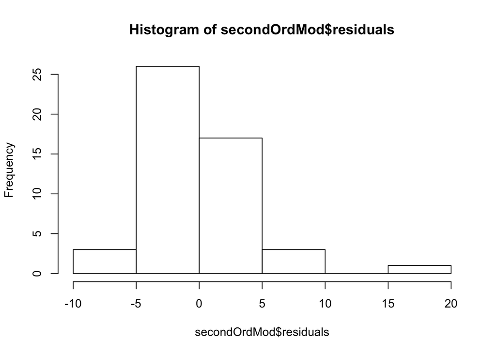

```r
hist(secondOrdMod$residuals)
```

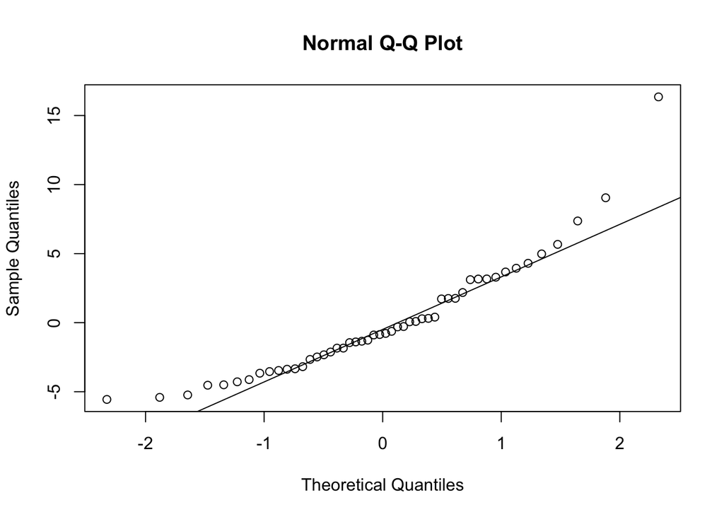

```r
qqnorm(secondOrdMod$residuals)
qqline(secondOrdMod$residuals)
```